# ST502: Project 1

Ming Cai & Lamia Benyamine

2024-10-08

# INTRODUCTION

There are many methods to approximate the probability of success, p, from a Binomial random sample, however, not all have the same coverage probabilities or average length of the confidence interval. This report will review several different methods using R and compare the performance of the confidence intervals for various sample sizes and probabilities for these three properties:

- The proportion of intervals that capture the true value
- The proportion that miss above and proportion that miss below
- The average length of the interval

- Wald interval
- Adjusted Wald interval
- Clopper-Pearson (exact) interval
- Score interval
- Raw percentile interval using a parametric bootstrap
- Bootstrap t interval using a parametric bootstrap.

# SIMULATION METHODS

*Note: We will use* $\alpha = 0.05$ *as default in all calculations.* Also, *for all methods, when* $y = 0$*, we set the interval to be* $[0,0]$ *and when* $y = n$*, we set the interval to be* $[1,1]$*.*

## Wald Interval

The formula of calculating Wald interval is:

$$\hat{p} - z_{1-\frac{\alpha}{2}}\sqrt{\frac{\hat{p}(1-\hat{p})}{n}} <
p < \hat{p} +
z_{1-\frac{\alpha}{2}}\sqrt{\frac{\hat{p}(1-\hat{p})}{n}},$$

where the $z_c$ denotes the $c$ quantile of the standard normal distribution. To calculate the Wald interval for $p$, we need to use sample’s probability $\hat{p}$, sample size $n$ and the confidence level $1-\alpha$.

The function for calculating the Wald Interval is given below:

```r
WaldCI <- function(y, n, alpha = 0.05){
 # Initialize vectors to store lower and upper intervals
  lower_intervals <- numeric(length(y))
  upper_intervals <- numeric(length(y))

  # Loop through each success value
  for (i in seq_along(y)) {
      # Estimate of the probability of success
      p_hat = y[i]/n
    # Special cases for y = 0 or y = n
    if (y[i] == 0) {
      lower_intervals[i] <- 0
      upper_intervals[i] <- 0
    } else if (y[i] == n) {
      lower_intervals[i] <- 1
      upper_intervals[i] <- 1
    } else {
      # Calculate the Wald CI
      lower_intervals[i] <- p_hat - qnorm(1-alpha/2)*sqrt((p_hat*(1-p_hat))/n)
      upper_intervals[i] <- p_hat + qnorm(1-alpha/2)*sqrt((p_hat*(1-p_hat))/n)
    }
  }
  # Return the lists of lower and upper intervals
  return(list(Lower = lower_intervals, Upper = upper_intervals))
}
```

## Adjusted Wald interval

where $\tilde{p} = (Y+2)/(n+4)$.

The function for calculating the Adjusted Wald Interval is given below:

```r
AdjWaldCI <- function(y, n, alpha = 0.05) {
 # Initialize vectors to store lower and upper intervals
  lower_intervals <- numeric(length(y))
  upper_intervals <- numeric(length(y))

  # Loop through each success value
  for (i in seq_along(y)) {
    # Calculate adjusted estimate of probability of success
    p_tilde <- (y[i] + 2) / (n + 4)

    # Special cases for y = 0 or y = n
    if (y[i] == 0) {
      lower_intervals[i] <- 0
      upper_intervals[i] <- 0
    } else if (y[i] == n) {
      lower_intervals[i] <- 1
      upper_intervals[i] <- 1
    } else {
      # Calculate the adjusted Wald CI
      lower_intervals[i] <- p_tilde - qnorm(1 - alpha / 2) * sqrt((p_tilde * (1 - p_tilde)) / (n + 4))
      upper_intervals[i] <- p_tilde + qnorm(1 - alpha / 2) * sqrt((p_tilde * (1 - p_tilde)) / (n + 4))
    }
  }
  # Return the lists of lower and upper intervals
  return(list(Lower = lower_intervals, Upper = upper_intervals))
}
```

## Clopper-Pearson (exact) interval

Clopper-Pearson interval is referred to as an “exact” interval. This interval is guaranteed to have coverage probability of at least $1 - \alpha$ for every value of $p$. When $y = 1,2, \cdots , n - 1$, the confidence interval is:

$$\left[ 1 + \frac{n-y+1}{yF_{2y,2(n-y+1),\frac{\alpha}{2}}} \right]^{-1}
< p < \left[ 1 +
\frac{n-y}{(y+1)F_{2(y+1),2(n-y),1-\frac{\alpha}{2}}} \right]^{-1},$$

where the $F_{a,b,c}$ denotes the $c$ quantile from the F distribution with degrees of freedom $a$ and $b$.

The function for calculating the Clopper-Pearson interval is given below:

```r
ClopperPearsonCI <- function(y, n, alpha = 0.05){
 # Initialize vectors to store lower and upper intervals
  lower_intervals <- numeric(length(y))
  upper_intervals <- numeric(length(y))

  # Loop through each success value
  for (i in seq_along(y)) {

   # Special cases for y = 0 or y = n
    if (y[i] == 0) {
      lower_intervals[i] <- 0
      upper_intervals[i] <- 0
    } else if (y[i] == n) {
      lower_intervals[i] <- 1
      upper_intervals[i] <- 1
    } else {
      # Calculate the general case for Clopper-Pearson CI using F-distribution
      lower_intervals[i] <- 1 / (1 + ((n-y[i]+1) / (y[i] * qf(alpha/2, 2*y[i], 2*(n-y[i]+1)))))
      upper_intervals[i] <- 1 / (1 + ((n-y[i]) / ((y[i]+1) * qf(1-(alpha/2), 2*(y[i]+1), 2*(n-y[i])))))
    }
  }
 # Return the lists of lower and upper intervals
  return(list(Lower = lower_intervals, Upper = upper_intervals))
}
```

## Score interval

Score tests, and in particular their standard errors, are based on the log-likelihood at the null hypothesis value of the parameter, whereas Wald tests are based on the log-likelihood at the maximum likelihood estimate. Score interval can be used with almost all sample sizes and $p$ values. The formula is given below:

$$\frac{\hat{p}+\frac{z_{1-\frac{\alpha}{2}}^2}{2n}-z_{1-\frac{\alpha}{2}}\sqrt{\frac{\hat{p}(1-\hat{p})
+
\frac{z_{1-\frac{\alpha}{2}}^2}{4n}}{n}}}{1+\frac{z_{1-\frac{\alpha}{2}}^2}{n}}
< p <
\frac{\hat{p}+\frac{z_{1-\frac{\alpha}{2}}^2}{2n}+z_{1-\frac{\alpha}{2}}\sqrt{\frac{\hat{p}(1-\hat{p})
+
\frac{z_{1-\frac{\alpha}{2}}^2}{4n}}{n}}}{1+\frac{z_{1-\frac{\alpha}{2}}^2}{n}},$$

where the $z_c$ denotes the $c$ quantile of the standard normal distribution.

The function for calculating the Score interval is given below:

```r
ScoreCI <- function(y, n, alpha = 0.05){
  # Z-score for the desired confidence level
  z = qnorm(1-alpha/2)
  # Initialize vectors to store lower and upper intervals
  lower_intervals <- numeric(length(y))
  upper_intervals <- numeric(length(y))

  # Loop through each success value
  for (i in seq_along(y)) {
    # Estimate of the probability of success
    p_hat = y[i]/n
    # Special cases for y = 0 or y = n
    if (y[i] == 0) {
      lower_intervals[i] <- 0
      upper_intervals[i] <- 0
    } else if (y[i] == n) {
      lower_intervals[i] <- 1
      upper_intervals[i] <- 1
    } else {
      # Calculate the Score CI
      lower_intervals[i] <-
      (p_hat + z^2/(2*n) - z*sqrt((p_hat*(1-p_hat) + z^2/(4*n))/n)) / (1 + z^2/n)
      upper_intervals[i] <-
      (p_hat + z^2/(2*n) + z*sqrt((p_hat*(1-p_hat) + z^2/(4*n))/n)) / (1 + z^2/n)
    }
  }
  # Return the lists of lower and upper intervals
  return(list(Lower = lower_intervals, Upper = upper_intervals))
}
```

## Raw percentile interval and Bootstrap t interval function (both using a parametric bootstrap)

To find the Raw percentile interval, we need to find the $\frac{\alpha}{2}$ quantile and the $1-\frac{\alpha}{2}$ quantile of the $\hat{p}$ of samples.

$$\hat{p}_{\frac{\alpha}{2}} < p < \hat{p}_{1-\frac{\alpha}{2}}$$

where the $\hat{p}_{c}$ denotes the $c$ quantile of the proportion of the samples.

To find the Bootstrap t interval, we use following steps:

1. Calculate the mean of our sample’s $\hat{p}$ to generate bootstrapped $\hat{p}_{boot}$,
2. Use the mean of bootstrapped $\hat{p}_{boot}$ to generate secondary bootstrapped $\hat{p}_{boot2}$,
3. Use secondary bootstrapped $\hat{p}_{boot2}$ to find the estimated standard error of $\hat{p}_{boot}$,
4. Calculate the interval based on formula.

$$\hat{p} - t_{1-{\frac{\alpha}{2}}}\cdot \hat{SE} < p < \hat{p} -
t_{\frac{\alpha}{2}}\cdot \hat{SE}$$

where the $t_{c}$ denotes the $c$ quantile of the bootstrapped t values, and

$$T =
\frac{\underset{\sim}{\hat{p}}-p}{\underset{\sim}{\hat{SE}}(\underset{\sim}{\hat{p}})}$$

The function for finding the Raw percentile interval and the Bootstrap t interval is given below:

```r
BootstrapCI <- function(y, n, B, alpha = 0.05) {
  # Initialize vectors to store lower and upper intervals
  raw_lower <- numeric(length(y))
  raw_upper <- numeric(length(y))
  boot_t_interval_low <- numeric(length(y))
  boot_t_interval_up <- numeric(length(y))

  set.seed(4321)
  # Loop through each success value
  for (i in seq_along(y)) {
      # Estimate the proportion
      p_hat <- y[i] / n

      # Bootstrap t interval calculations
      boot_estimates <- replicate(B, {
      sim_data <- rbinom(1, n, prob = p_hat)  # Generate bootstrap sample
      p_hat_boot <- sim_data / n  # Bootstrap estimate of proportion

      # Return NA if p_hat_boot is 0 or 1
      if (p_hat_boot == 0 || p_hat_boot == 1) {
        return(c(NA, NA))
      }
      # Perform secondary bootstrap for standard error estimation
      B2 <- 50
      secondary_boot <- replicate(B2, {
        sim_data2 <- rbinom(1, n, prob = p_hat_boot)  # Second bootstrap sample
        p_hat_boot2 <- sim_data2 / n  # Bootstrap estimate
        return(p_hat_boot2)
      })

      # Find SE for t-stat
      estimated_SE_p_hat_boot <- sd(secondary_boot)  # Standard error
      if (estimated_SE_p_hat_boot == 0) return(c(NA, NA))  # Handle division by zero

      # Calculate t-statistic
      p_boot_t <- (p_hat_boot - p_hat) / estimated_SE_p_hat_boot
      return(c(p_hat_boot, p_boot_t))
    })

    # Calculate raw percentile interval from bootstrap samples
    raw_lower[i] <- quantile(boot_estimates[1, ], alpha / 2, na.rm = TRUE)
    raw_upper[i] <- quantile(boot_estimates[1, ], 1 - alpha / 2, na.rm = TRUE)

    # Filter out invalid p_hat_boot and infinite t-statistics
    valid_boot_est <- na.omit(boot_estimates[1, ])
    valid_t_stat <- boot_estimates[2, is.finite(boot_estimates[2, ])]

    # Calculate the t-bootstrap intervals using quantiles of valid t-stats
    boot_t_interval_low[i] <- p_hat - quantile(valid_t_stat, 1 - alpha / 2, na.rm = TRUE) * sd(valid_boot_est)
    boot_t_interval_up[i] <- p_hat - quantile(valid_t_stat, alpha / 2, na.rm = TRUE) * sd(valid_boot_est)
  }

  # combine intervals into one list
  raw_interval <- list(Lower = raw_lower, Upper = raw_upper)
  t_interval <- list(Lower = boot_t_interval_low, Upper = boot_t_interval_up)

  # Return both raw percentile and t-bootstrap intervals
  return(list(raw_boot = raw_interval, t_boot = t_interval))
}
```

## Creation of Data

We generated $N = 1000$ random samples from a binomial distribution where sample size $n$ varies across 15, 30, to 100 and true proportion $p$ varies from 0.01 to 0.99 (15 total values of p).

```r
# Set values
N <- 1000 # Number of random samples
n <- c(15, 30, 100) # Values of n
p <- seq(0.01, 0.99, length.out = 15) # Values of p

# Set seed to allow for replication of data
set.seed(4321)
# Function to generate random binomial sample data for each combination of n and p
GetData <- function(n_vals, p_vals, N = N) {
  # Initialize a list to store sample data
  sample_data <- list()
  for (n in n_vals) {
    for (p in p_vals) {
      samples <- rbinom(N, size = n, prob = p)  # Generate N binomial samples
      col_name <- paste0("n", n, "p", p)  # Create column name for the dataset
      sample_data[[col_name]] <- samples  # Store samples in the list
    }
  }
  return(sample_data)
}
sample_data <- GetData(n, p, N)
```

## Execute the Monte Carlo simulation

### Wald Simulation

```r
# Initialize a data frame to store the results
waldci_results <- data.frame()

for (col_name in names(sample_data)) {
    samples <- sample_data[[col_name]]  # Get the samples
    # Extract the n and p values from the column name
    n_value <- as.numeric(sub("n(\\d+)p.*", "\\1", col_name))
    true_p <- as.numeric(sub(".*p(\\d+\\.\\d+)", "\\1", col_name))

    # Compute the CI
    ci <- WaldCI(samples, n_value)

    # Store results
    waldci_results <- rbind(waldci_results, data.frame(
      Method = "Wald",
      Sample = col_name,
      True_P = true_p,
      Size = n_value,
      # Check if the true p value is within the CI
      Coverage_rate = mean((ci[[1]] <= true_p) & (ci[[2]] >= true_p)),
      Miss_Above = mean((ci[[2]] < true_p)),  # True p is above CI
      Miss_Below = mean((ci[[1]] > true_p)),   # True p is below CI
      Width = mean(ci[[2]] - ci[[1]]) # Width of interval
  ))
}
# Aggregate by taking the average of the properties
Wald_Properties <- aggregate(cbind(Coverage_rate, Miss_Above, Miss_Below, Width) ~ Size, data = waldci_results, FUN = mean)
```

### Adjusted Wald Simulation

```r
# Initialize a data frame to store the results
adjwaldci_results <- data.frame()

for (col_name in names(sample_data)) {
    samples <- sample_data[[col_name]]  # Get the samples
    # Extract the n and p values from the column name
    n_value <- as.numeric(sub("n(\\d+)p.*", "\\1", col_name))
    true_p <- as.numeric(sub(".*p(\\d+\\.\\d+)", "\\1", col_name))

    # Compute the CI
    ci <- AdjWaldCI(samples, n_value)

    # Store results
    adjwaldci_results <- rbind(adjwaldci_results, data.frame(
      Method = "ADJWald",
      Sample = col_name,
      True_P = true_p,
      Size = n_value,
      # Check if the true p value is within the CI
      Coverage_rate = mean((ci[[1]] <= true_p) & (ci[[2]] >= true_p)),
      Miss_Above = mean((ci[[2]] < true_p)),  # True p is above CI
      Miss_Below = mean((ci[[1]] > true_p)),   # True p is below CI
      Width = mean(ci[[2]] - ci[[1]]) # Width of interval
  ))
}
# Aggregate by taking the average of the properties
Adj_Wald_Properties <- aggregate(cbind(Coverage_rate, Miss_Above, Miss_Below, Width) ~ Size, data = adjwaldci_results, FUN = mean)
```

### Clopper Pearson Simulation

```r
# Initialize a data frame to store the results
cpci_results <- data.frame()

for (col_name in names(sample_data)) {
    samples <- sample_data[[col_name]]  # Get the samples
    # Extract the n and p values from the column name
    n_value <- as.numeric(sub("n(\\d+)p.*", "\\1", col_name))
    true_p <- as.numeric(sub(".*p(\\d+\\.\\d+)", "\\1", col_name))

    # Compute the CI
    ci <- ClopperPearsonCI(samples, n_value)

   # Store results
    cpci_results <- rbind(cpci_results, data.frame(
      Method = "CP",
      Sample = col_name,
      True_P = true_p,
      Size = n_value,
      # Check if the true p value is within the CI
      Coverage_rate = mean((ci[[1]] <= true_p) & (ci[[2]] >= true_p)),
      Miss_Above = mean((ci[[2]] < true_p)),  # True p is above CI
      Miss_Below = mean((ci[[1]] > true_p)),   # True p is below CI
      Width = mean(ci[[2]] - ci[[1]]) # Width of interval
  ))
}
# Aggregate by taking the average of the properties
CP_Properties <- aggregate(cbind(Coverage_rate, Miss_Above, Miss_Below, Width) ~ Size, data = cpci_results, FUN = mean)
```

### Score Interval Simulation

```r
# Initialize a data frame to store the results
scoreci_results <- data.frame()

# Loop through each sample in sample_data to compute CIs
for (col_name in names(sample_data)) {
  samples <- sample_data[[col_name]]  # Get the samples
  # Extract the n and p values from the column name
  n_value <- as.numeric(sub("n(\\d+)p.*", "\\1", col_name))
  true_p <- as.numeric(sub(".*p(\\d+\\.\\d+)", "\\1", col_name))

  # Compute the CI
  ci <- ScoreCI(samples, n_value)

  # Store results
  scoreci_results <- rbind(scoreci_results, data.frame(
    Method = "Score",
    Sample = col_name,
    True_P = true_p,
    Size = n_value,
    # Check if the true p value is within the CI
    Coverage_rate = mean((ci[[1]] <= true_p) & (ci[[2]] >= true_p)),
    Miss_Above = mean((ci[[2]] < true_p)),  # True p is above CI
    Miss_Below = mean((ci[[1]] > true_p)),   # True p is below CI
    Width = mean(ci[[2]] - ci[[1]]) # Width of interval
  ))
}
# Aggregate by taking the average of the properties
Score_Properties <- aggregate(cbind(Coverage_rate, Miss_Above, Miss_Below, Width) ~ Size, data = scoreci_results, FUN = mean)
```

### Bootstrap Interval Simulation (Raw percentile & t-interval)

```r
# Initialize a data frame to store the results and set the replication values
raw_bootci_results <- data.frame()
t_bootci_results <- data.frame()
B = 100
B2 = 50

# Loop through each sample in sample_data to compute CIs
for (col_name in names(sample_data)) {
  samples <- sample_data[[col_name]]  # Get the samples
  # Extract the n and p values from the column name
  n_value <- as.numeric(sub("n(\\d+)p.*", "\\1", col_name))
  true_p <- as.numeric(sub(".*p(\\d+\\.\\d+)", "\\1", col_name))

  # Compute the CI
  ci <- BootstrapCI(samples, n_value, B)

    # Store results for raw percentile bootstrap method
  raw_bootci_results <- rbind(raw_bootci_results, data.frame(
    Method = "Raw-boot",
    Sample = col_name,
    True_P = true_p,
    Size = n_value,
    # Check if the true p value is within the CI
    Coverage_rate = mean((ci[[1]][[1]] <= true_p) & (ci[[1]][[2]] >= true_p)),
    Miss_Above = mean((ci[[1]][[2]] < true_p)),  # True p is above CI
    Miss_Below = mean((ci[[1]][[1]] > true_p)),   # True p is below CI
    Width = mean(ci[[1]][[2]] - ci[[1]][[1]]) # Width of interval
  ))

    # Store results for t-interval bootstrap method
  t_bootci_results <- rbind(t_bootci_results, data.frame(
    Method = "t-interval",
    Sample = col_name,
    True_P = true_p,
    Size = n_value,
    # Check if the true p value is within the CI
    Coverage_rate = mean((ci[[2]][[1]] <= true_p) & (ci[[2]][[2]] >= true_p)),
    Miss_Above = mean((ci[[2]][[2]] < true_p)),  # True p is above CI
    Miss_Below = mean((ci[[2]][[1]] > true_p)),   # True p is below CI
    Width = mean(ci[[2]][[2]] - ci[[2]][[1]]) # Width of interval
  ))
}
# Aggregate by taking the average of the properties
Raw_Boot_Properties <- aggregate(cbind(Coverage_rate, Miss_Above, Miss_Below, Width) ~ Size, data = raw_bootci_results, FUN = mean)
t_Interval_Boot_Properties <- aggregate(cbind(Coverage_rate, Miss_Above, Miss_Below, Width) ~ Size, data = t_bootci_results, FUN = mean)
```

# RESULTS

## Summary Table

Combining the results from the properties of all the above methods into a table.

```r
# Add an attribute column
Wald_Properties$Method <- "Wald"
Adj_Wald_Properties$Method <- "AdjWald"
CP_Properties$Method <- "CP"
Score_Properties$Method <- "Score"
Raw_Boot_Properties$Method <- "Raw-% boot"
t_Interval_Boot_Properties$Method <- "t-int boot"

library(dplyr)
# Combine all tables into one
combined_properties <- arrange(rbind(Wald_Properties, Adj_Wald_Properties, CP_Properties, Score_Properties, Raw_Boot_Properties, t_Interval_Boot_Properties), Size)
combined_properties
```

```
##    Size Coverage_rate Miss_Above Miss_Below     Width     Method
## 1    15     0.7840000 0.10760000 0.10840000 0.3483881       Wald
## 2    15     0.8008000 0.09786667 0.10133333 0.3371066    AdjWald
## 3    15     0.8162000 0.09033333 0.09346667 0.3747014         CP
## 4    15     0.7832000 0.10573333 0.11106667 0.3266059      Score
## 5    15     0.9217500 0.04400000 0.03425000 0.4471075 Raw-% boot
## 6    15     0.9512500 0.03275000 0.01600000 0.5441098 t-int boot
## 7    30     0.8386667 0.08026667 0.08106667 0.2565721       Wald
## 8    30     0.8546667 0.07166667 0.07366667 0.2566973    AdjWald
## 9    30     0.8640000 0.06793333 0.06806667 0.2767912         CP
## 10   30     0.8492667 0.07446667 0.07626667 0.2500642      Score
## 11   30     0.9214286 0.04000000 0.03857143 0.3186768 Raw-% boot
## 12   30     0.9595714 0.02028571 0.02014286 0.3592770 t-int boot
## 13  100     0.8933333 0.05260000 0.05406667 0.1452071       Wald
## 14  100     0.9121333 0.04460000 0.04326667 0.1470158    AdjWald
## 15  100     0.9197333 0.04113333 0.03913333 0.1536079         CP
## 16  100     0.8985333 0.05113333 0.05033333 0.1448942      Score
## 17  100     0.9395385 0.02946154 0.03100000 0.1554125 Raw-% boot
## 18  100     0.9421538 0.02884615 0.02900000 0.1670028 t-int boot
```

## Coverage Probability Grid

This is a Comparison of Coverage Probabilities for the alpha 95% Wald, Adjusted Wald, Clopper-Pearson, Score, and Bootstrap Intervals for each sample size.

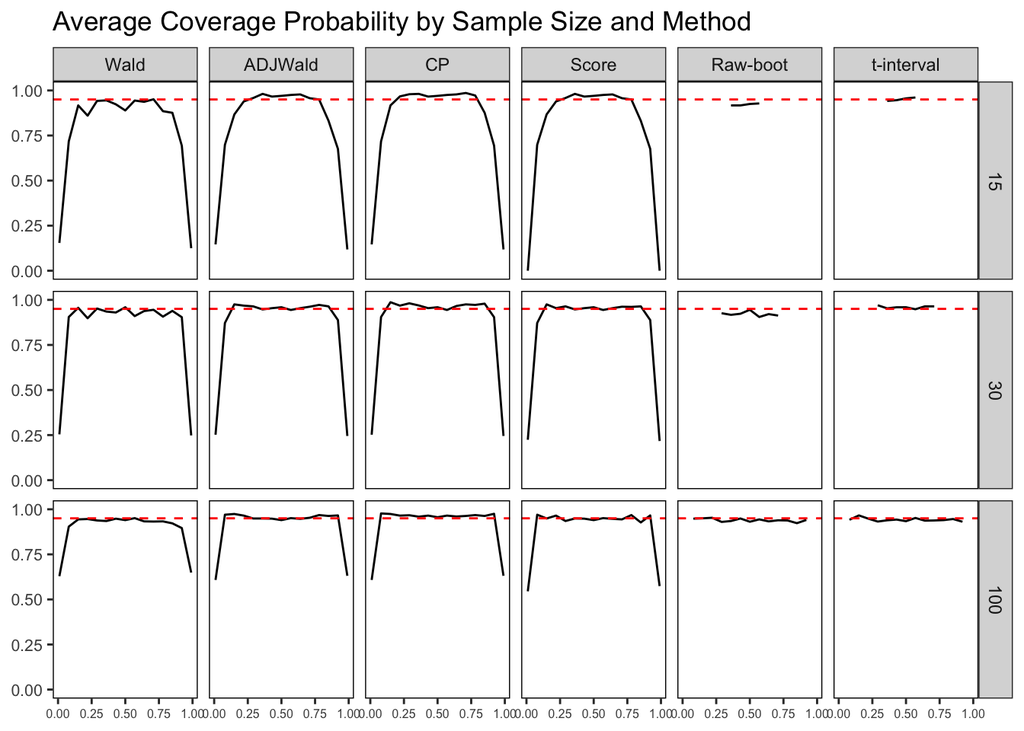

```r
library(ggplot2)
library(tidyr)
#combine all the CI results to get the coverage probability by p value
combined_results <- rbind(waldci_results, adjwaldci_results, cpci_results, scoreci_results, raw_bootci_results, t_bootci_results)

# Set the order of Method as a factor
combined_results$Method <- factor(combined_results$Method, levels = c("Wald", "ADJWald", "CP", "Score", "Raw-boot", "t-interval"))

# Create the line graph for Coverage Probability
combined_results |>
ggplot(aes(x = True_P, y = Coverage_rate)) +
  geom_line(size = 0.5) +
  labs(title = "Average Coverage Probability by Sample Size and Method") +
  facet_grid(Size ~ Method) +
  geom_hline(yintercept = 0.95, linetype = "dashed", color = "red") +
  coord_cartesian(ylim = c(0, 1)) + # Set y-axis limits from 0 to 1
  theme_bw() +
  theme(  # Remove major & minor grid lines and keep borders.Update x-axis label to avoid overlap
    panel.grid.major = element_blank(), panel.grid.minor = element_blank(), panel.border = element_rect(color = "black"), axis.text.x = element_text(size = 6), axis.text.y = element_text(size = 8), axis.title.x = element_blank(), axis.title.y = element_blank())
```

## Interval Length Grid

This is a Comparison of interval lengths for the alpha 95% Wald, Adjusted Wald, Clopper-Pearson, Score, and Bootstrap Intervals for each sample size.

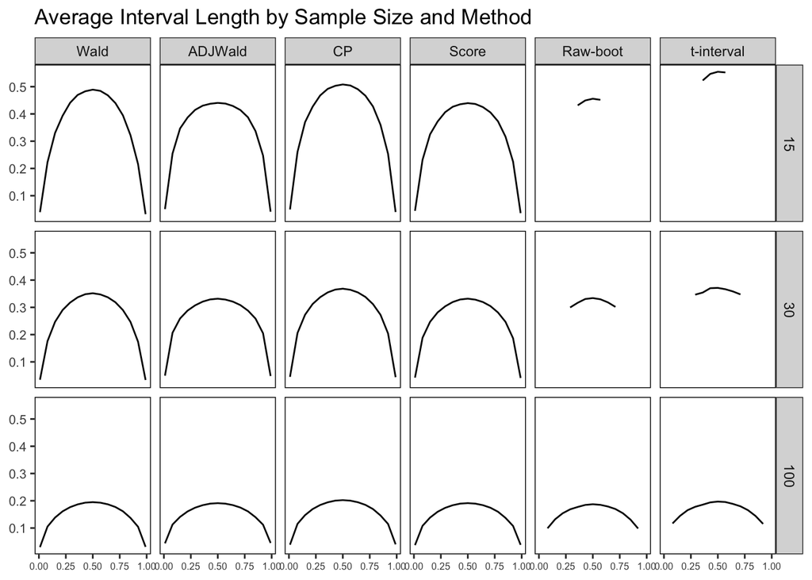

```r
# Create the line graph for Interval Length
combined_results |>
ggplot(aes(x = True_P, y = Width)) +
  geom_line(size = 0.5) +
  labs(title = "Average Interval Length by Sample Size and Method") +
  facet_grid(Size ~ Method) +
  theme_bw() +
  theme(  # Remove major & minor grid lines and keep borders.Update x-axis label to avoid overlap
    panel.grid.major = element_blank(), panel.grid.minor = element_blank(), panel.border = element_rect(color = "black"), axis.text.x = element_text(size = 6), axis.text.y = element_text(size = 8), axis.title.x = element_blank(), axis.title.y = element_blank())
```

### Standard Error of Interval Widths

```r
# Calculate average interval length and standard error
average_lengths <- combined_results |>
  group_by(Size, Method) |>
  summarise(
    Avg_Width = mean(Width, na.rm = TRUE),
    SE_Width = sd(Width, na.rm = TRUE) / sqrt(n()), .groups = 'drop') |>
  pivot_wider(
    names_from = Size,
    values_from = c(Avg_Width, SE_Width))
average_lengths
```

```
## # A tibble: 6 × 7
##   Method     Avg_Width_15 Avg_Width_30 Avg_Width_100 SE_Width_15 SE_Width_30
##   <fct>             <dbl>        <dbl>         <dbl>       <dbl>       <dbl>
## 1 Wald              0.348        0.257         0.145     0.0400      0.0277
## 2 ADJWald           0.337        0.257         0.147     0.0345      0.0242
## 3 CP                0.375        0.277         0.154     0.0406      0.0280
## 4 Score             0.327        0.250         0.145     0.0350      0.0250
## 5 Raw-boot          0.447        0.319         0.155     0.00277     0.00357
## 6 t-interval        0.544        0.359         0.167     0.00377     0.00268
## # ℹ 1 more variable: SE_Width_100 <dbl>
```

## Review Results

# CONCLUSION

Rank the coverage probabilities and the interval lengths by method to find an overall best method.

```r
ranked_prop <- combined_properties |>
  group_by(Size) |>
  arrange(desc(Coverage_rate)) |>
  mutate(Coverage_Rank = row_number()) |>
  arrange(Width) |>
  mutate(length_Rank = row_number())

avg_ranks_by_method <- ranked_prop |>
  group_by(Method) |>
  summarise(
    Avg_Coverage_Rank = mean(Coverage_Rank, na.rm = TRUE),
    Avg_Length_Rank = mean(length_Rank, na.rm = TRUE), .groups = 'drop')

# Now average those averages for a final ranking
final_avg_ranks <- avg_ranks_by_method |>
  group_by(Method) |>
  summarise(Overall_Avg_Rank = mean(c(Avg_Coverage_Rank, Avg_Length_Rank)), .groups = 'drop') |>
  arrange(Overall_Avg_Rank)
final_avg_ranks
```

```
## # A tibble: 6 × 2
##   Method     Overall_Avg_Rank
##   <chr>                 <dbl>
## 1 Score                  3.17
## 2 AdjWald                3.33
## 3 CP                     3.5
## 4 Raw-% boot             3.5
## 5 t-int boot             3.5
## 6 Wald                   4
```

Based on these results, the Score interval has the overall best results across all sample sizes. There are other more complex methods for creating confidence intervals that could be tested, along with increasing the number of samples that are taken for each method and size.